# Analisis 10 Kategori Film yang Paling Sering Disewa

shifa Noor Maulidia/C/M0725086

2026-05-26

#Library

```r
library(DBI)
library(odbc)
library(ggplot2)
library(knitr)
```

# Pendahuluan

Database Sakila merupakan database simulasi rental film yang disediakan oleh MySQL. Database ini berisi berbagai informasi seperti actor, address, category, city, country, customer, film, film actor, film category, film text, inventory, language, payment, rental, staff,dan store. Pada laporan ini dilakukan analisis mengenai kategori film yang paling sering disewa oleh customer. Analisis ini bertujuan untuk mengetahui kategori film yang paling diminati sehingga dapat membantu perusahaan rental dalam menentukan strategi bisnis dan pengelolaan stok film.

# Insight Analisis

Insight utama yang dianalisis adalah **10 kategori film yang paling sering disewa** pada database Sakila. Dengan analisis ini dapat diketahui preferensi customer terhadap jenis film tertentu.

# Koneksi Database

mengkoneksikan database MySQL, yaitu sakila dengan Rstudio menggunakan fungsi `dbConnect()`

```r
koneksidata1 <- DBI::dbConnect(odbc::odbc(),
Driver = "MySQL ODBC 8.0 ANSI Driver",
Server = "127.0.0.1",
Database = "sakila",
UID = "root",
PWD = "shifalia66", #sesuaikan dg password masing-masing
Port = 3306)
```

# Mengambil Data

Setelah terkoneksi dengan SQL, kita menggunakan blok kode SQL untuk mendapatkan data jumlah sewa dari tiap-tiap kategori film, dan menyimpan data hasil kueri data dalam data frame data_kategori

```r
query1 <- "
SELECT
category.name AS kategori,
COUNT(rental.rental_id) AS jumlah_rental
FROM category
JOIN film_category
ON category.category_id = film_category.category_id
JOIN inventory
ON film_category.film_id = inventory.film_id
JOIN rental
ON inventory.inventory_id = rental.inventory_id
GROUP BY category.name
ORDER BY jumlah_rental DESC
"

data_kategori <- dbGetQuery(koneksidata1, query1)

print(data_kategori)
```

```
##       kategori jumlah_rental
## 1       Sports          1179
## 2    Animation          1166
## 3       Action          1112
## 4       Sci-Fi          1101
## 5       Family          1096
## 6        Drama          1060
## 7  Documentary          1050
## 8      Foreign          1033
## 9        Games           969
## 10    Children           945
## 11      Comedy           941
## 12         New           940
## 13    Classics           939
## 14      Horror           846
## 15      Travel           837
## 16       Music           830
```

# Ringkasan Data

Ringkasan data menampilkan ringkasan statistik deskriptif dari data, seperti nilai minimal, kuartil pertama, median, rata-rata, kuartil ketiga, dan maksimal

```r
knitr::kable(data_kategori,
             caption = "Jumlah rental film berdasarkan kategori film",
             col.names = c("Kategori Film", "jumlah Rental"))
```

Jumlah rental film berdasarkan kategori film

| Kategori Film | jumlah Rental |
| --- | --- |
| Sports | 1179 |
| Animation | 1166 |
| Action | 1112 |
| Sci-Fi | 1101 |
| Family | 1096 |
| Drama | 1060 |
| Documentary | 1050 |
| Foreign | 1033 |
| Games | 969 |
| Children | 945 |
| Comedy | 941 |
| New | 940 |
| Classics | 939 |
| Horror | 846 |
| Travel | 837 |
| Music | 830 |

```r
summary(data_kategori)
```

```
##    kategori         jumlah_rental
##  Length:16          Min.   : 830
##  Class :character   1st Qu.: 940
##  Mode  :character   Median : 969
##                     Mean   :1002
##                     3rd Qu.:1096
##                     Max.   :1179
```

# Analisis Statistik

Analisis statistik deskriptif digunakan untuk melihat gambaran umum data rental film pada database Sakila. Statistik deskriptif membantu memahami distribusi data melalui nilai minimum, kuartil, median, mean, dan maksimum.

## Mean (Rata-rata)

Mean digunakan untuk mengetahui rata-rata jumlah rental pada setiap kategori film.

$$\bar{x} = \frac{\sum x}{n}$$

Keterangan:

- $\bar{x}$ = rata-rata data
- $\sum x$ = total seluruh data
- $n$ = jumlah data

Penjelasan:  
Mean menunjukkan rata-rata jumlah rental dari seluruh kategori film pada database Sakila.

## Median

Median merupakan nilai tengah dari data yang telah diurutkan.

$$Me = \frac{n+1}{2}$$

Keterangan:

- $Me$ = median
- $n$ = jumlah data

Penjelasan:  
Median digunakan untuk melihat nilai tengah jumlah rental kategori film.

## Kuartil 1 (Q1)

Kuartil 1 menunjukkan seperempat data terendah.

$$Q_1 = \frac{1(n+1)}{4}$$

Keterangan:

- $Q_1$ = kuartil pertama
- $n$ = jumlah data

Penjelasan:  
Kuartil 1 membantu mengetahui batas bawah distribusi data rental.

## Kuartil 3 (Q3)

Kuartil 3 menunjukkan seperempat data tertinggi.

$$Q_3 = \frac{3(n+1)}{4}$$

Keterangan:

- $Q_3$ = kuartil ketiga
- $n$ = jumlah data

Penjelasan:  
Kuartil 3 digunakan untuk melihat batas atas distribusi data rental.

# TOP 10 Kategori Film Yang Paling Sering Disewa

Menampilkan 10 kategori film dengan jumlah sewa yang banyak.

```r
query2 <- "
SELECT
category.name AS kategori,
COUNT(rental.rental_id) AS jumlah_rental
FROM category
JOIN film_category
ON category.category_id = film_category.category_id
JOIN inventory
ON film_category.film_id = inventory.film_id
JOIN rental
ON inventory.inventory_id = rental.inventory_id
GROUP BY category.name
ORDER BY jumlah_rental DESC
LIMIT 10
"

TOP10_data_kategori <- dbGetQuery(koneksidata1, query2)

print(TOP10_data_kategori)
```

```
##       kategori jumlah_rental
## 1       Sports          1179
## 2    Animation          1166
## 3       Action          1112
## 4       Sci-Fi          1101
## 5       Family          1096
## 6        Drama          1060
## 7  Documentary          1050
## 8      Foreign          1033
## 9        Games           969
## 10    Children           945
```

# Visualisasi Kategori Film Paling Sering Disewa

```
## Defaulting to continuous.
## Defaulting to continuous.
```

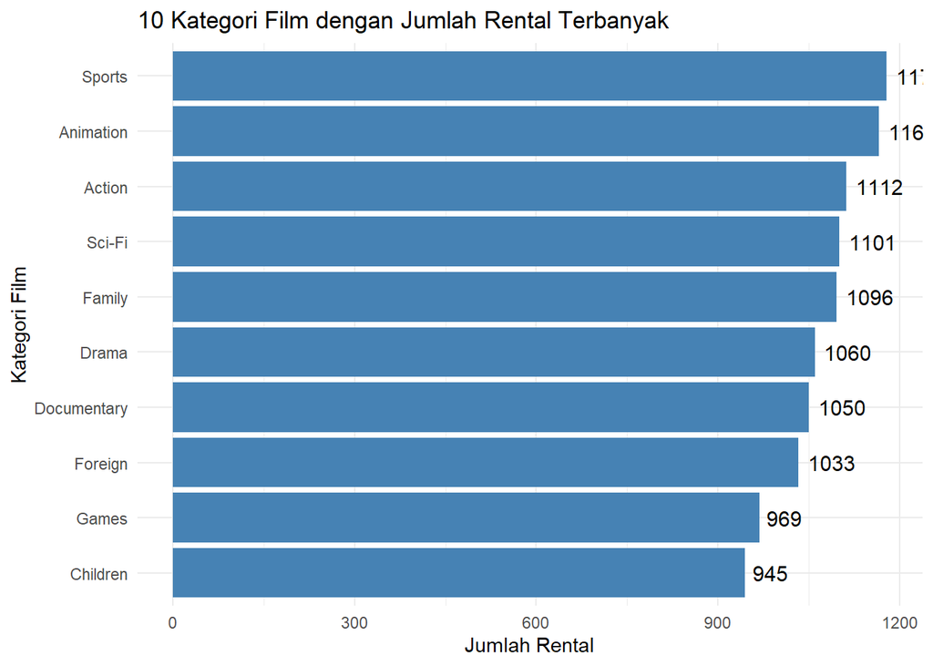

```r
ggplot(TOP10_data_kategori,
       aes(x = reorder(kategori, jumlah_rental),
           y = jumlah_rental)) +

  geom_col(fill = "steelblue") +

  geom_text(aes(label = jumlah_rental),
            hjust = -0.2,
            size = 4) +

  coord_flip() +

  labs(
    title = "10 Kategori Film dengan Jumlah Rental Terbanyak",
    x = "Kategori Film",
    y = "Jumlah Rental"
  ) +

  theme_minimal()
```

# Interpretasi Data

Visualisasi data dilakukan menggunakan diagram batang (*bar chart*) untuk menampilkan 10 kategori film dengan jumlah rental tertinggi pada database Sakila. kategori film yang memasuki top 10 dengan jumlah rental terbanyak adalah sports, animasi, aksi, sci-fi, keluarga, family, drama, dokumenter, foreign, permainan, dan anak-anak Berdasarkan diagram di atas, dapat kita lihat bahwa film dengan kategori **sports** memiliki jumlah rental terbanyak dengan total 1.179. Hal ini menunjukkan bahwa para customer lebih tertarik pada film bertema olahraga. Sedangkan film berkategori **anak-anak** merupakan kategori film yang menempati urutan ke-10 jumlah rental terbanyak dengan total 945.

Selain itu, kategori **Animasi**, **Keluarga**, dan **anak-anak** juga cukup populer, yang menunjukkan bahwa film keluarga dan anak-anak banyak diminati. Kategori **Aksi** dan **Sci-Fi** menunjukkan bahwa customer juga menyukai film dengan adegan menegangkan dan unsur imajinasi. Sementara itu, kategori **Drama** dan **Documenter** menunjukkan adanya minat terhadap film yang bersifat emosional dan informatif.

Secara keseluruhan, hasil analisis menunjukkan bahwa preferensi customer terhadap kategori film cukup beragam sehingga informasi ini dapat dimanfaatkan perusahaan rental untuk menentukan strategi promosi dan pengelolaan stok film.